# Group Project Proposal

Group 3 - Yuhui Luo, Adlai Stevenson, Kevin Wong, Kailun Zheng

4/11/2018

# Group Members

**Names - NetIDs:**  
Yuhui Luo - yuhuil2  
Adlai Stevenson - aesteve2  
Kevin Wong - kjwong2  
Kailun Zheng - kailunz2

# Project Details

## Tentative Title

Predicting Default Status of Credit Card Clients

## Background Information

Statistics from Financial Supervisory Commission (FSC) of Taiwan show that $3.49 billion out of $4.93 billion in bad loans in 2006 (70.78%) came from the section of non-performing credit card loans (“non-performing” means that the sum of borrowed money could not be paid back within scheduled payments for at least 90 days). To avoid problems from getting worse, banks had tightened credit policies for unsecured lending and gradually established credit rating systems ever since.

By examining the relationships among default status, cardholders’ information, and payment history, we would like to better understand the default pattern in 2005. Being able to predict whether a debtor would default would have equipped the card issuers more capability and credibility when making the decision of accepting or rejecting a credit card application. More importantly, it would have identified the happening of credit card crisis in an earlier stage. These historical learnings could provide valuable insights when US credit card companies look into expanding their business to Taiwan in the future.

## Goal and Motivation

Our **goal** is to predict default status of Taiwanese credit card clients from 2005.  
Our **motivation** behind this project is that many people in Taiwan could not pay off their credit cards. This was bad for the credit card companies and also Taiwanese citizens. Credit card companies lost money, and many Taiwanese people committed suicide as a result from defaulting. We want to use this project to help companies and customers predict whether or not they’ll default before they purchase a credit card.

## Statistical Learning Task

Classification (of Credit Card Default Status)

# Data

## Data Source

https://archive.ics.uci.edu/ml/datasets/default+of+credit+card+clients#

## Data Information

```r
credit_data = read.csv("credit_data.csv")
head(credit_data$DEFAULT, 20)
```

```
##  [1] 1 1 0 0 0 0 0 0 0 0 0 0 0 1 0 0 1 0 0 0
```

```r
dim(credit_data)
```

```
## [1] 30000    25
```

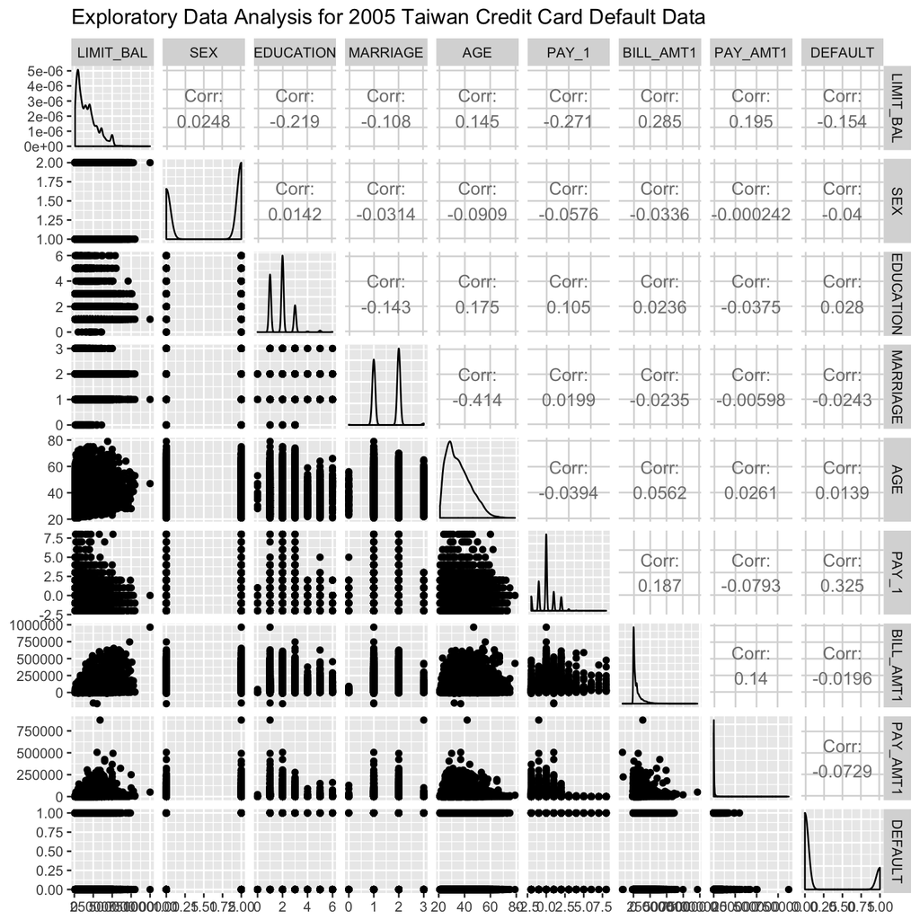

```r
glm_mod = glm(DEFAULT ~ ., data = credit_data, family = "binomial")
head(predict(glm_mod, credit_data, type = "response"))
```

```
##         1         2         3         4         5         6
## 0.5107773 0.1526606 0.2035793 0.2463999 0.1402590 0.2427982
```

# Data Dictionary

[output not shown]

**NOTE:** When we loaded the data, all of the variables are integer variables as default. When we begin the actual project, we will adjust these variables accordingly.

# Sources

https://archive.ics.uci.edu/ml/datasets/default+of+credit+card+clients#

[http://www.vrl-financial-news.com/cards–payments/cards-international/issues/ci-2007/ci375/taiwan%E2%80%99s-credit-crisis-the-ca.aspx](http://www.vrl-financial-news.com/cards--payments/cards-international/issues/ci-2007/ci375/taiwan%E2%80%99s-credit-crisis-the-ca.aspx)

https://sevenpillarsinstitute.org/case-studies/taiwans-credit-card-crisis/